# Final project( Spatial statistics)

Olufemi Olamijulo

2023-12-13

Data sources Covid data from: The Covid Tracking Project https://covidtracking.com/data/download State boundary shape file from: Eric Tech https://eric.clst.org/tech/usgeojson/ Data of Political parties by state (2023)from: World Population Review https://worldpopulationreview.com/state-rankings/political-parties-by-state I used also used an extra file called states_abr also from World Population review https://worldpopulationreview.com/states/state-abbreviations to translate and merge the files above.

```r
require('readr')
```

```r
require('ggplot2')
library(dplyr)
library(spdep)
library(sf)
```

```r
# Read in dataset
Data <- read.csv('all-states-history.csv')

# Convert the 'date' column to a Date object and create 'months_of_covid'
Data$date <- as.Date(Data$date)
Data$year <- as.numeric(format(Data$date, "%Y"))
Data$month <- as.numeric(format(Data$date, "%m"))
Data$months_of_covid <- (Data$year - 2020) * 12 + Data$month - (1 - 1)

Data$month_year <- paste(month.name[(Data$months_of_covid - 1) %% 12 + 1], 2020 + (Data$months_of_covid - 1) %/% 12)


# Calculating daily new positive cases to avoid double counting our values
Data <- Data %>%
  arrange(state, date) %>%
  group_by(state) %>%
  mutate(daily_positive = positive - lag(positive, default = first(positive))) %>%
  ungroup()

# Summarize daily new positive cases by months of covid
monthly_positive_cases <- Data %>%
  group_by(months_of_covid) %>%
  summarize(total_positive = sum(daily_positive, na.rm = TRUE))
```

```r
# Summarize daily new positive cases by state and months of covid
monthly_positive_cases_by_state <- Data %>%
  group_by(state, months_of_covid, month_year) %>%
  summarize(total_positive = sum(daily_positive, na.rm = TRUE)) %>%
  ungroup()
# Viewing the first few rows of the summarized data
head(monthly_positive_cases_by_state)
```

```
## # A tibble: 6 x 4
##   state months_of_covid month_year  total_positive
##   <chr>           <dbl> <chr>                <int>
## 1 AK                  3 March 2020             125
## 2 AK                  4 April 2020             227
## 3 AK                  5 May 2020               108
## 4 AK                  6 June 2020              481
## 5 AK                  7 July 2020             2049
## 6 AK                  8 August 2020           2293
```

```r
# Read the spatial data
united_states <- st_read('gz_2010_us_040_00_500k.json')
# Read the political leanings and other state data
political_leanings <- read.csv('political-parties-by-state-2023.csv')
states_abr <- read.csv('table-data.csv')

# Rename the relevant column in the spatial data to 'state'
united_states <- united_states %>%
  rename(state = NAME)

# Rename abbreviated state name column to 'code' in monthly positive cases data
monthly_positive_cases_by_state <- monthly_positive_cases_by_state %>%
  rename(code = state)

# Exclude specific codes and 'Puerto Rico' from the datasets
excluded_codes <- c("PR", "GU", "MP", "AS", "VI", "AK", "HI")
monthly_positive_cases_by_state <- monthly_positive_cases_by_state %>%
  filter(!code %in% excluded_codes)

political_leanings <- political_leanings %>%
  filter(!state %in% c("Alaska"))

states_abr <- states_abr %>%
  filter(!code %in% excluded_codes)

united_states <- united_states %>%
  filter(!state %in% c("Puerto Rico", "Alaska"))

# Merge monthly positive cases with state abbreviations
merged_data_1 <- merge(monthly_positive_cases_by_state, states_abr, by = "code", all = TRUE)

# Merge political_leanings with new data
merged_data_2 <- merge(political_leanings, merged_data_1, by = "state", all = TRUE)

# Merge the spatial data with the new merged data
final_merged_data <- merge(united_states, merged_data_2, by = "state", all = TRUE)

final_merged_data <- final_merged_data %>%
  filter(months_of_covid > 3)
```

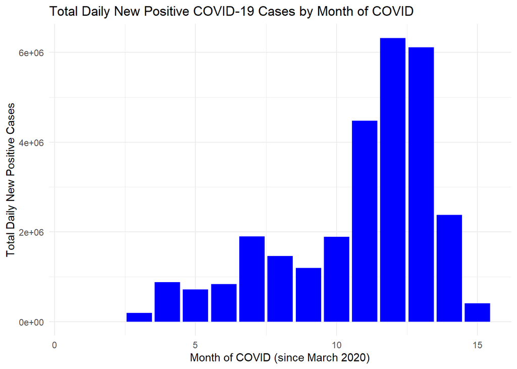

```r
# Plotting
library(ggplot2)
ggplot(monthly_positive_cases, aes(x = months_of_covid, y = total_positive)) +
  geom_bar(stat = "identity", fill = "blue") +
  labs(title = "Total Daily New Positive COVID-19 Cases by Month of COVID",
       x = "Month of COVID (since March 2020)",
       y = "Total Daily New Positive Cases") +
  theme_minimal()
```

#Though the distribution seems normal enough to run a regression on, it will propaly be more useful if we were trying to predic the covid month. Basically, using this distribution on a linear regression model starts to run into problems on a timescale. Such as many more cases we can expect with each additional month. Based on the outcomes, this approach will not be ideal.

Because I am more interested in predicting number of cases each month X based on a number of variable, we will be looking at different type of distribution.

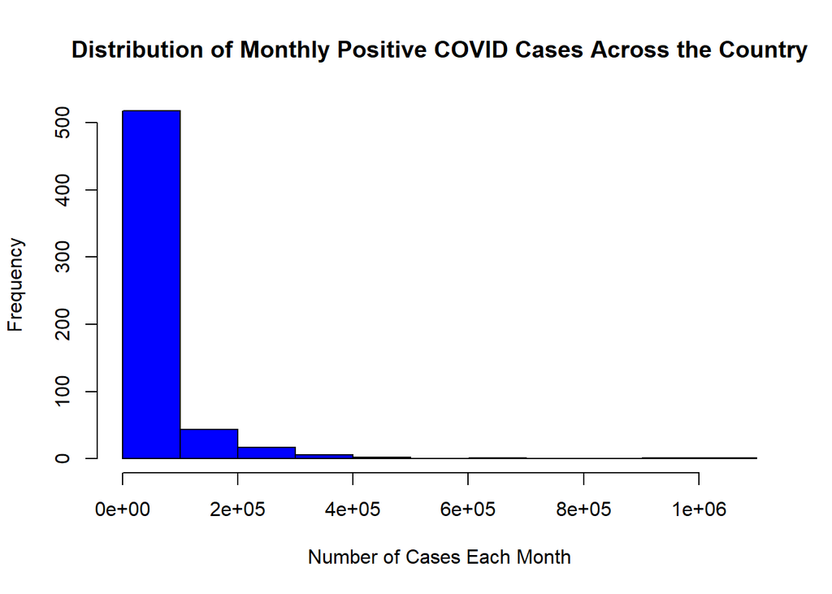

```r
final_merged_data$total_positive <- as.numeric(as.character(final_merged_data$total_positive))

hist(final_merged_data$total_positive,
     main = "Distribution of Monthly Positive COVID Cases Across the Country",
     xlab = "Number of Cases Each Month",
     col = "blue")
```

This is more like it. Our distribution is skewed right. This is because in the starting months, there were many small values testing positive. This increased later on, as we can see in the tail, and also caused an additional double volume in smaller number of positive tests as the pandemic wore off.

We will now log these values because of the skew and also filter out the first 3 months of the pandemic where only a handful of states had positive results.

```r
final_merged_data <- final_merged_data %>%
  mutate(log_total_positive = log(total_positive + 1))
```

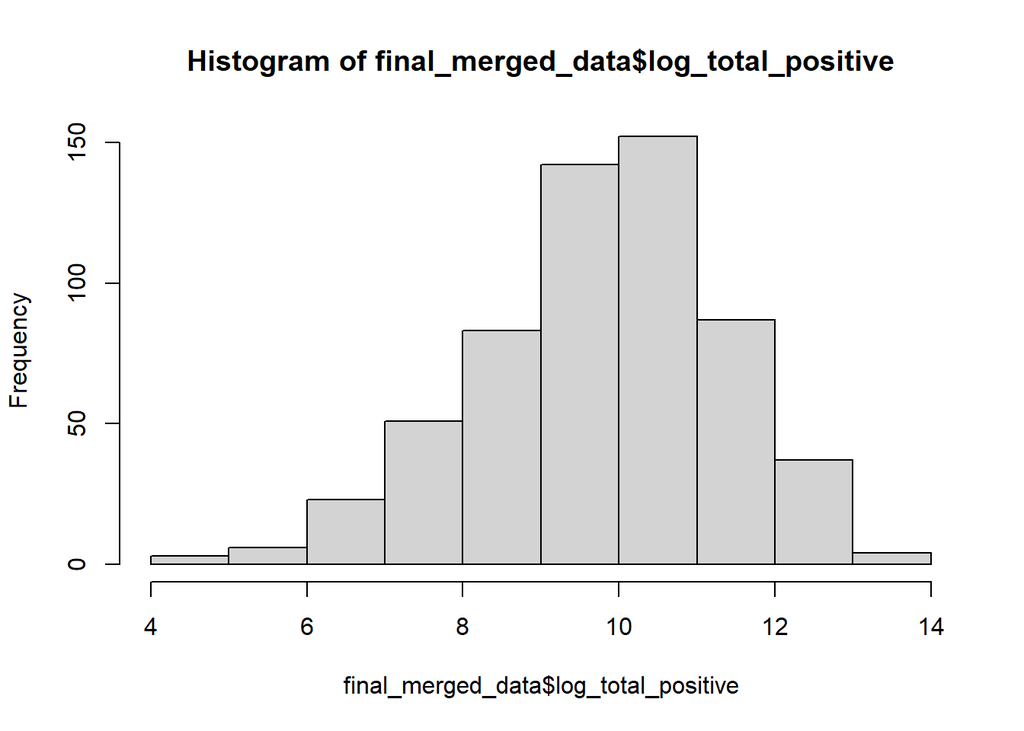

```r
hist(final_merged_data$log_total_positive)
```

I love spatial statistics!

# we did a log transform on all months because we are more interested in an overall pattern or trend than comparing cases from month to month. I will also be controlling for monthly variations in the dataset later in the regression model.

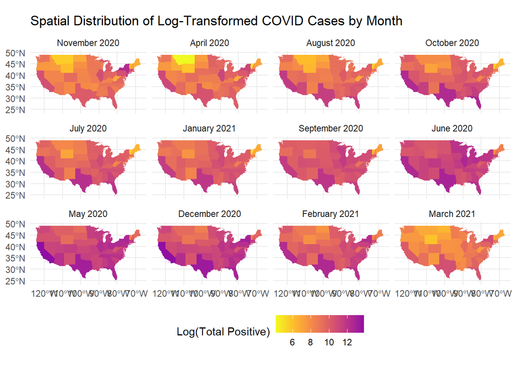

```r
month_labels <- setNames(final_merged_data$month_year, final_merged_data$months_of_covid)

# Custom labeller function
month_labeller <- function(variable, value) {
  month_labels[value]
}

ggplot(data = final_merged_data) +
  geom_sf(aes(fill = log_total_positive), color = NA) +  # Fill based on log_total_positive
  facet_wrap(~ months_of_covid, labeller = as_labeller(month_labeller)) +  # Separate map for each month
  scale_fill_viridis_c(option = "C", direction = -1, begin = 0.3, end = 1) +  # Viridis color scale
  labs(title = "Spatial Distribution of Log-Transformed COVID Cases by Month",
       fill = "Log(Total Positive)") +
  theme_minimal() +
  theme(legend.position = "bottom")
```

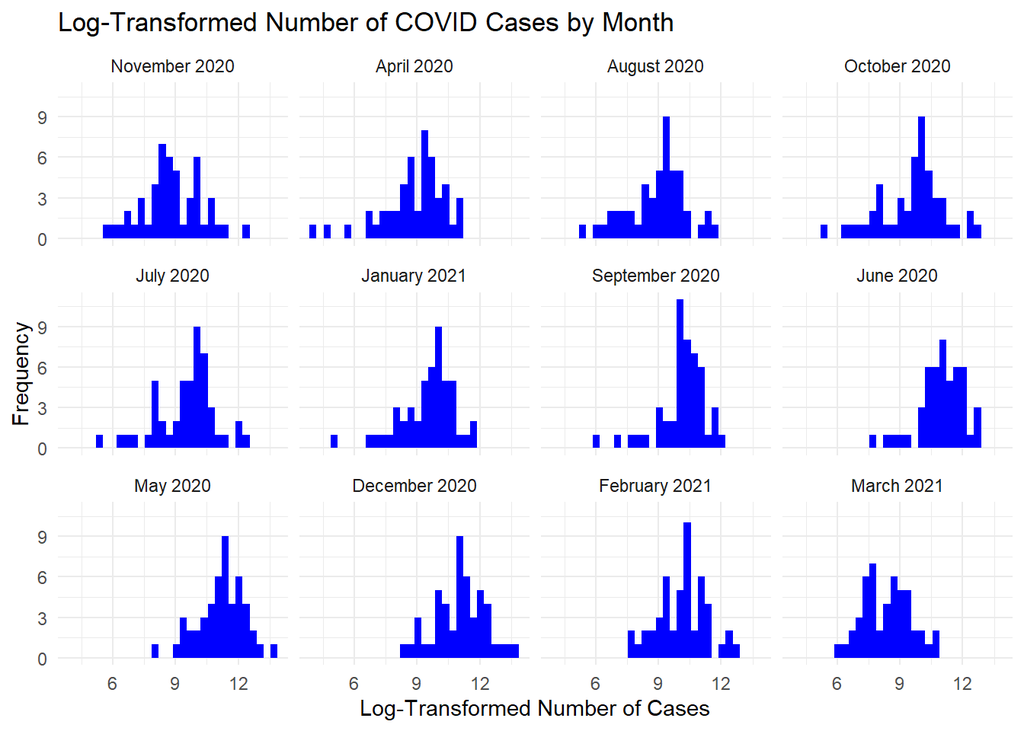

```r
ggplot(final_merged_data, aes(x = log_total_positive)) +
  geom_histogram(bins = 30, fill = "blue") +
  facet_wrap(~ months_of_covid, labeller = as_labeller(month_labeller)) + # Separate plot for each month
  labs(title = "Log-Transformed Number of COVID Cases by Month",
       x = "Log-Transformed Number of Cases",
       y = "Frequency") +
  theme_minimal()
```

```r
  # Create neighbors and weights for the entire country
nweights <- nb2listw(poly2nb(final_merged_data, queen = FALSE), style="W")
country_moran <- moran.test(final_merged_data$log_total_positive, nweights)
country_moran
```

```
##
##  Moran I test under randomisation
##
## data:  final_merged_data$log_total_positive
## weights: nweights
##
## Moran I statistic standard deviate = 30.57, p-value < 2.2e-16
## alternative hypothesis: greater
## sample estimates:
## Moran I statistic       Expectation          Variance
##      2.184258e-01     -1.703578e-03      5.185202e-05
```

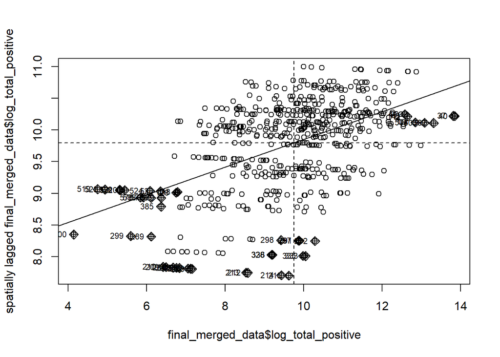

```r
moran.plot(final_merged_data$log_total_positive, nweights)
```

Our Moran’s I shows minor clustering (0.21), but my guess is that that’s because we are looking at multiple values across many months. Lets see what happens when we filter for each month.

Despite excluding Alaska and Hawaii, we’ll still have to exclude other polygons especially at those from the start of the pandemic because the few reported values for those early months will have no neighbors.

```r
unique(final_merged_data$state)
```

```
##  [1] "Alabama"              "Arizona"              "Arkansas"
##  [4] "California"           "Colorado"             "Connecticut"
##  [7] "Delaware"             "District of Columbia" "Florida"
## [10] "Georgia"              "Idaho"                "Illinois"
## [13] "Indiana"              "Iowa"                 "Kansas"
## [16] "Kentucky"             "Louisiana"            "Maine"
## [19] "Maryland"             "Massachusetts"        "Michigan"
## [22] "Minnesota"            "Mississippi"          "Missouri"
## [25] "Montana"              "Nebraska"             "Nevada"
## [28] "New Hampshire"        "New Jersey"           "New Mexico"
## [31] "New York"             "North Carolina"       "North Dakota"
## [34] "Ohio"                 "Oklahoma"             "Oregon"
## [37] "Pennsylvania"         "Rhode Island"         "South Carolina"
## [40] "South Dakota"         "Tennessee"            "Texas"
## [43] "Utah"                 "Vermont"              "Virginia"
## [46] "Washington"           "West Virginia"        "Wisconsin"
## [49] "Wyoming"
```

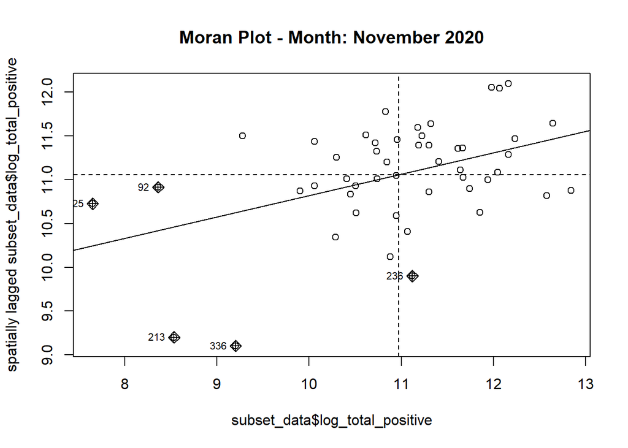

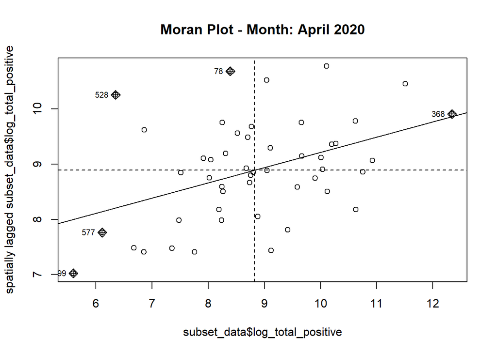

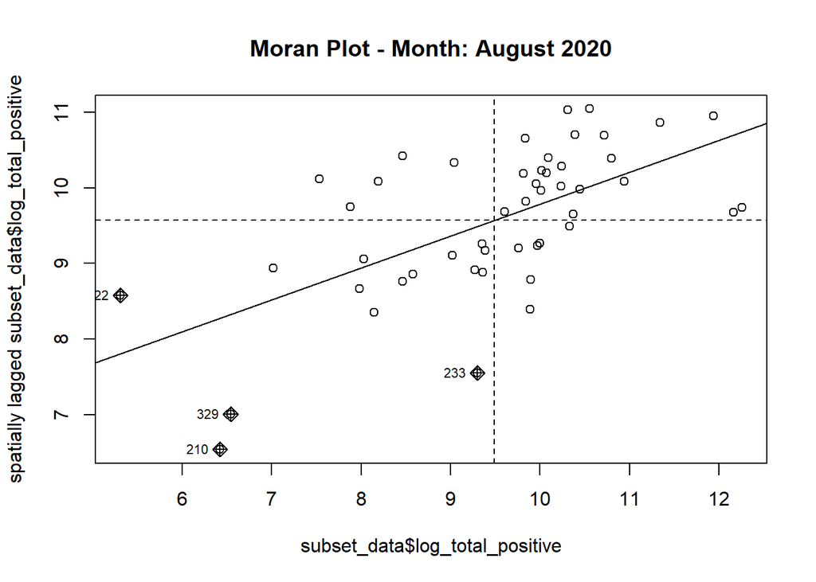

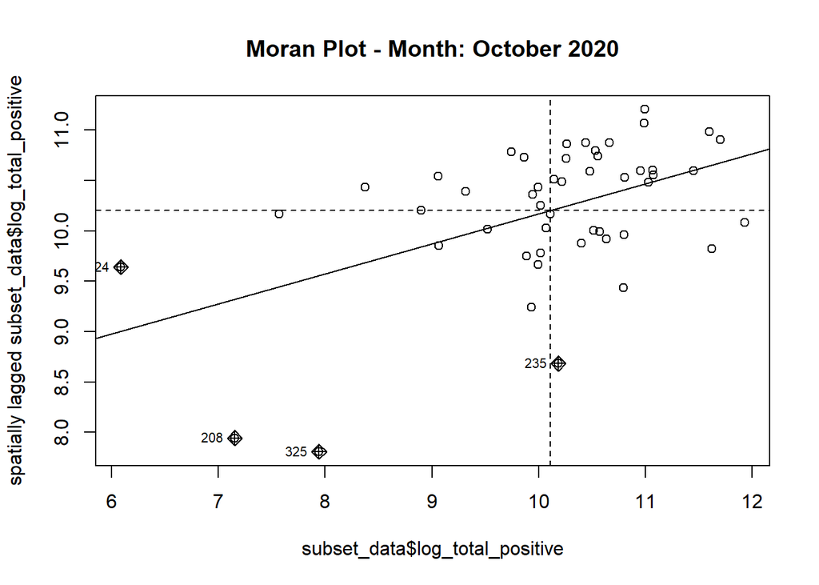

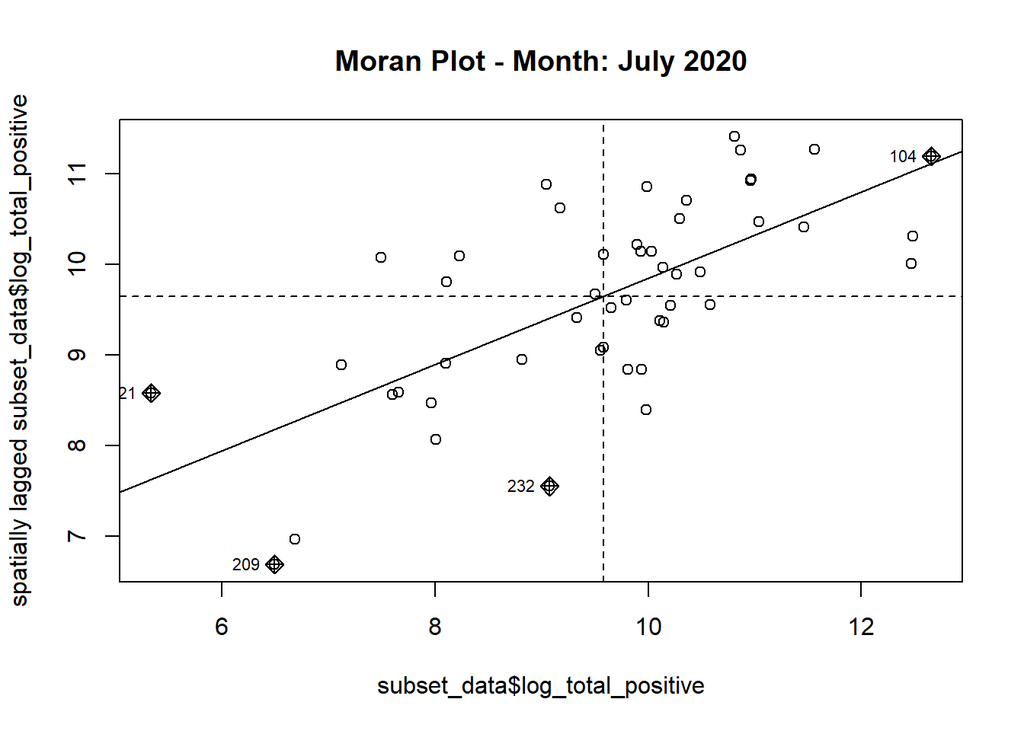

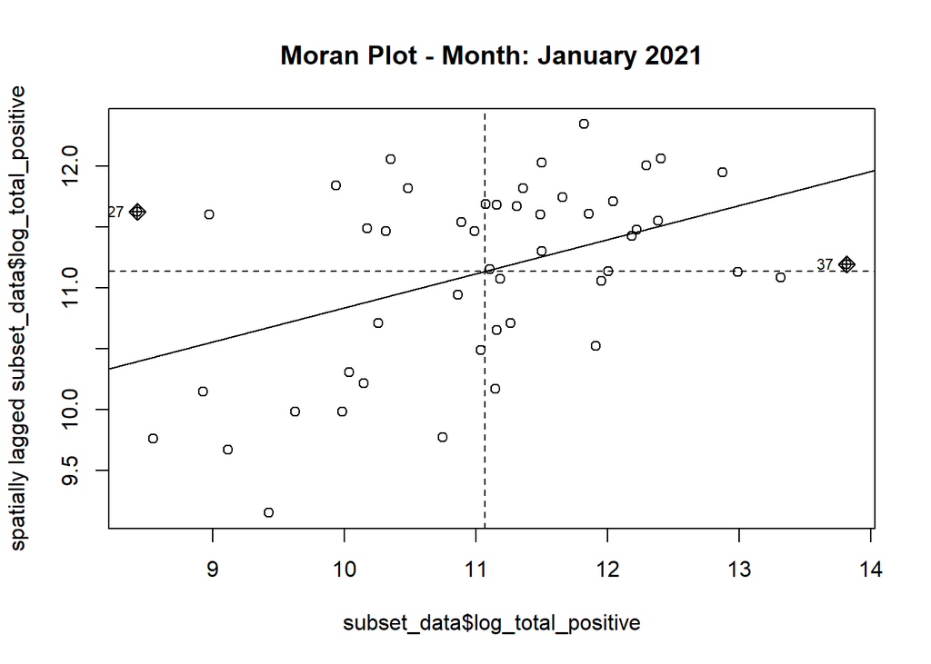

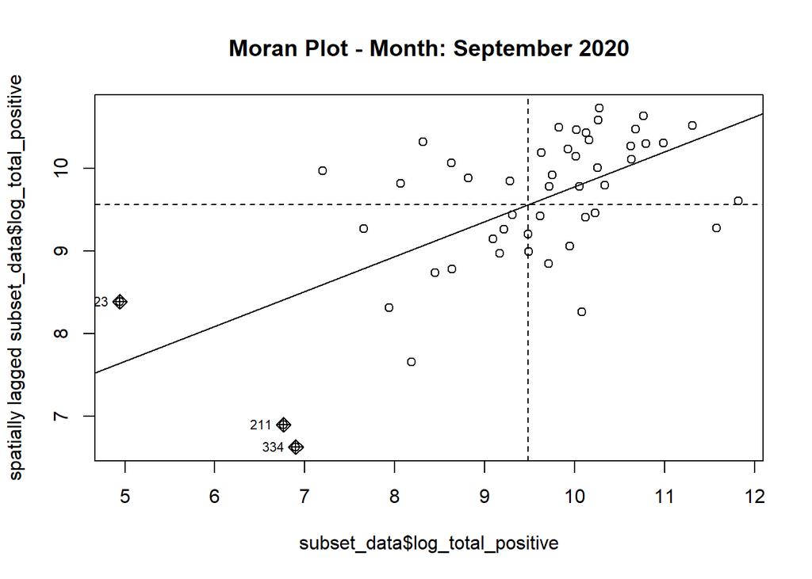

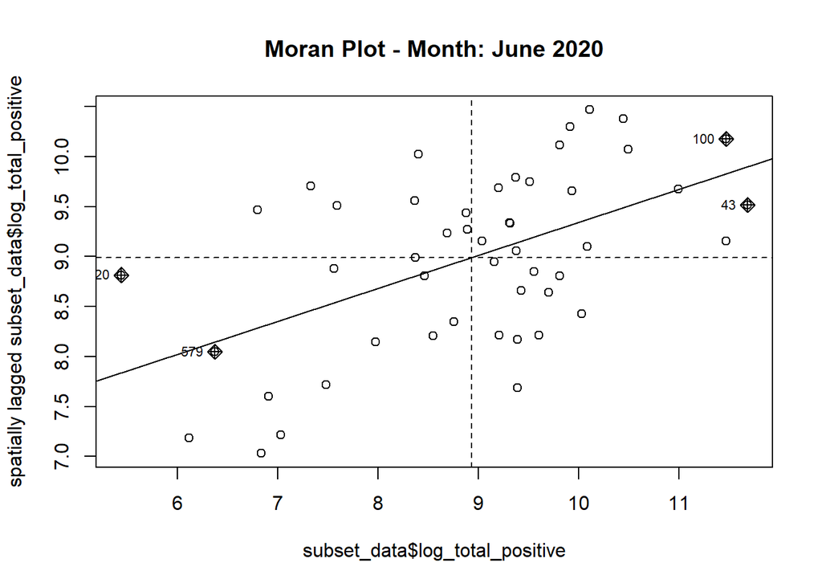

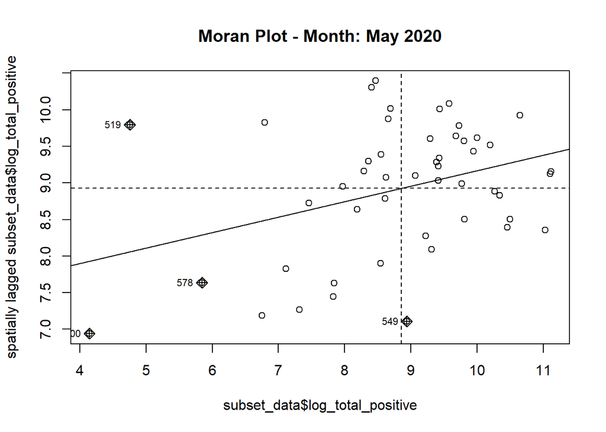

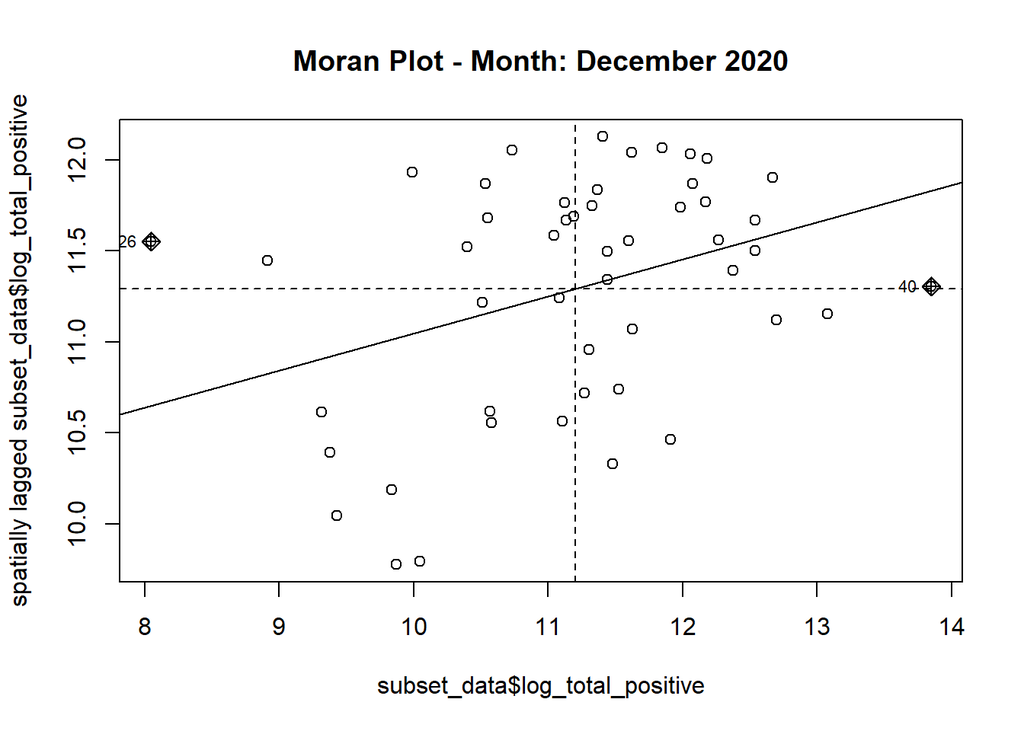

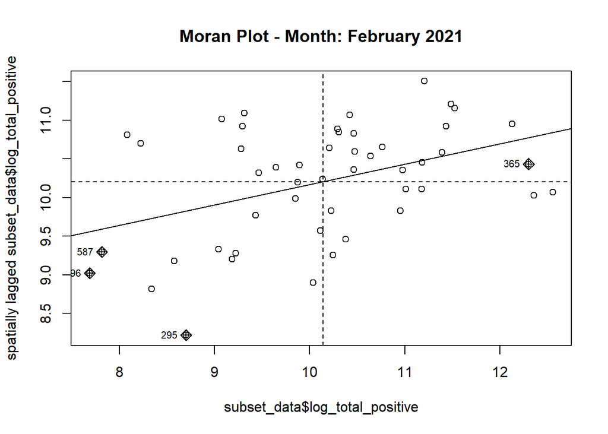

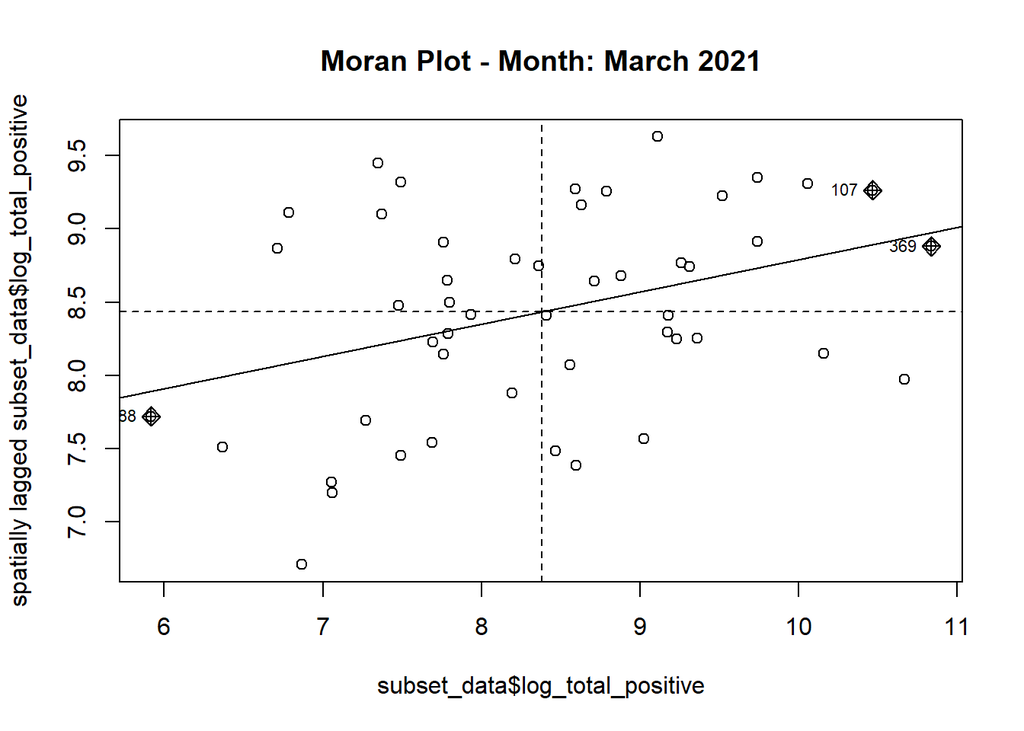

```r
# Initialize an empty list to store plots
plot_list <- list()
morans_list <-list()

# Loop through each unique month
for(month in unique(final_merged_data$month_year)){
  # Subset data for the specific month
  subset_data <- final_merged_data[final_merged_data$month_year == month, ]

  # Create neighbors and weights for the subset data
  neighbors <- poly2nb(subset_data, queen = FALSE)
  weights <- nb2listw(neighbors, style = "W")

  # Perform Moran's test
  state_moran <- moran.test(subset_data$log_total_positive, weights)

  # Create a base R plot (Moran plot) for each month
  plot_name <- paste("Moran Plot - Month:", subset_data$month_year[1])
  moran_plot <- moran.plot(subset_data$log_total_positive, weights, main = plot_name)

  # Store the plot and values in lists
    plot_list[[as.character(month)]] <- moran_plot
    morans_list[[as.character(month)]] <- list(
    Moran_I = state_moran$estimate["Moran I statistic"],
    Expectation = state_moran$estimate["Expectation"],
    Variance = state_moran$estimate["Variance"],
    p_value = state_moran$p.value)
}
```

```r
# Convert the list to a dataframe for easier viewing and analysis
morans_i_df <- do.call(rbind, morans_list)
rownames(morans_i_df) <- names(morans_list)

# Print the Moran's I values dataframe
print(morans_i_df)
```

```
##                Moran_I   Expectation Variance    p_value
## November 2020  0.2435437 -0.02083333 0.009217688 0.002946507
## April 2020     0.2760426 -0.02083333 0.009464126 0.001137936
## August 2020    0.4222027 -0.02083333 0.009301877 2.178256e-06
## October 2020   0.2984367 -0.02083333 0.008948183 0.0003689014
## July 2020      0.4758774 -0.02083333 0.009398069 1.49794e-07
## January 2021   0.2795763 -0.02083333 0.009500024 0.001027613
## September 2020 0.4213518 -0.02083333 0.009093217 1.76676e-06
## June 2020      0.3297464 -0.02083333 0.009472115 0.0001577903
## May 2020       0.2120432 -0.02083333 0.009145726 0.007443853
## December 2020  0.2032497 -0.02083333 0.009378838 0.01033807
## February 2021  0.2640421 -0.02083333 0.009546463 0.001774807
## March 2021     0.2204269 -0.02083333 0.009561493 0.006806715
```

## Run Standard OLS and control for time.

```r
ols <- lm(
  formula = log_total_positive ~ months_of_covid + PoliticalPartiesRepublicanLeanRep + PoliticalPartiesDemocratLeanDem + densityMi,
  data = final_merged_data
  )

summary(ols)
```

```
##
## Call:
## lm(formula = log_total_positive ~ months_of_covid + PoliticalPartiesRepublicanLeanRep +
##     PoliticalPartiesDemocratLeanDem + densityMi, data = final_merged_data)
##
## Residuals:
##     Min      1Q  Median      3Q     Max
## -5.1385 -0.8359  0.2044  1.0301  3.3599
##
## Coefficients:
##                                     Estimate Std. Error t value Pr(>|t|)
## (Intercept)                        1.406e+01  1.884e+00   7.461 3.13e-13 ***
## months_of_covid                    1.216e-01  1.785e-02   6.812 2.40e-11 ***
## PoliticalPartiesRepublicanLeanRep -7.620e-02  2.276e-02  -3.348 0.000868 ***
## PoliticalPartiesDemocratLeanDem   -5.496e-02  2.366e-02  -2.323 0.020508 *
## densityMi                         -2.012e-04  4.943e-05  -4.070 5.35e-05 ***
## ---
## Signif. codes:  0 '***' 0.001 '**' 0.01 '*' 0.05 '.' 0.1 ' ' 1
##
## Residual standard error: 1.494 on 583 degrees of freedom
## Multiple R-squared:  0.1125, Adjusted R-squared:  0.1064
## F-statistic: 18.47 on 4 and 583 DF,  p-value: 2.645e-14
```

Really intersting results! Variables such as the time of the pandemic, political leanings, and population density are all statistically significant predictors on the number of covid cases to expect each month.

Though we have very low R-squared values, our results indicate, on average, we can expect slightly fewer cases in Republican than Democrat states.

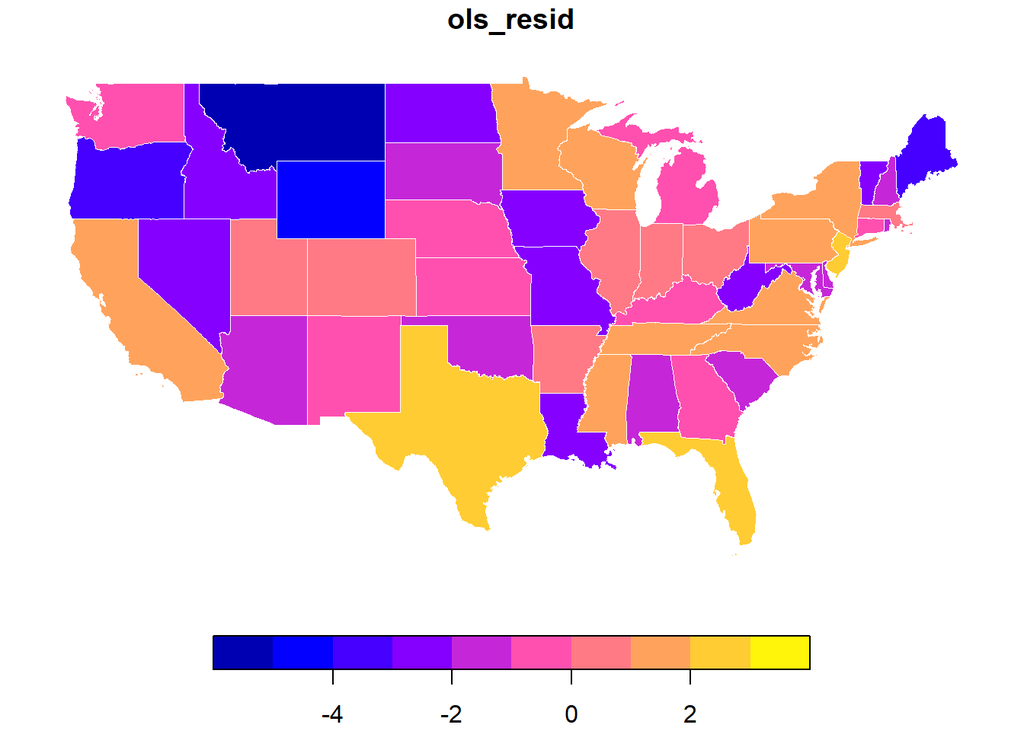

```r
final_merged_data$ols_resid <- residuals(ols)
plot(final_merged_data['ols_resid'],
     lwd=0.05,
     border=0
     )
```

Visual inspection shows some clustering in the midwest.

Testing residuals in a Moran’s test:

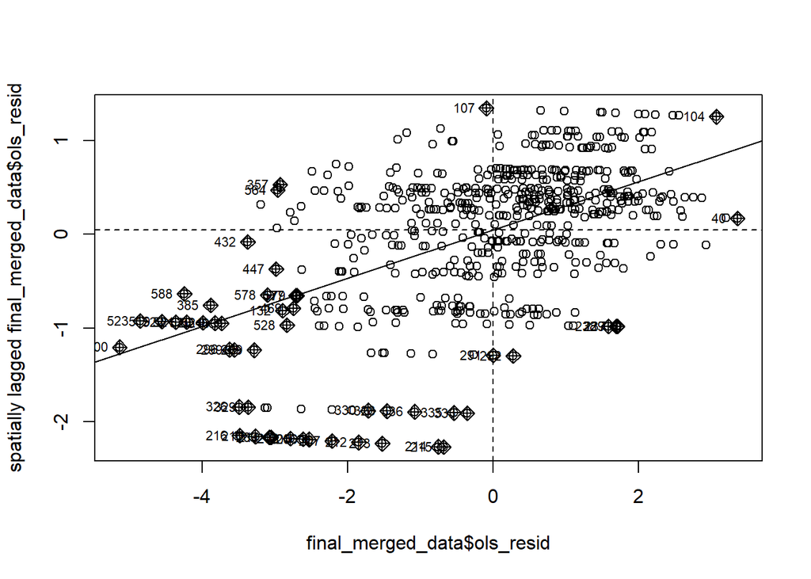

```r
moran.plot(final_merged_data$ols_resid, nweights)
```

```r
moran.test(final_merged_data$ols_resid, nweights)
```

```
##
##  Moran I test under randomisation
##
## data:  final_merged_data$ols_resid
## weights: nweights
##
## Moran I statistic standard deviate = 36.009, p-value < 2.2e-16
## alternative hypothesis: greater
## sample estimates:
## Moran I statistic       Expectation          Variance
##      2.575629e-01     -1.703578e-03      5.184117e-05
```

Moran’s I confirms this. Our values (.25) indicate some clustering. SO,we try out some spatial regression. ## Spatial Lag Modeling

```r
library(spatialreg)
lag <- lagsarlm(formula = log_total_positive ~ months_of_covid + PoliticalPartiesRepublicanLeanRep + PoliticalPartiesDemocratLeanDem + densityMi,
  data = final_merged_data,
  listw = nweights)

summary(lag)
```

```
##
## Call:
## lagsarlm(formula = log_total_positive ~ months_of_covid + PoliticalPartiesRepublicanLeanRep +
##     PoliticalPartiesDemocratLeanDem + densityMi, data = final_merged_data,
##     listw = nweights)
##
## Residuals:
##      Min       1Q   Median       3Q      Max
## -4.03452 -0.74605  0.15454  0.88378  3.03913
##
## Type: lag
## Coefficients: (asymptotic standard errors)
##                                      Estimate  Std. Error z value  Pr(>|z|)
## (Intercept)                        6.2411e+00  1.7663e+00  3.5335 0.0004101
## months_of_covid                    1.2350e-01  1.5283e-02  8.0809 6.661e-16
## PoliticalPartiesRepublicanLeanRep -8.3777e-02  2.0120e-02 -4.1639 3.128e-05
## PoliticalPartiesDemocratLeanDem   -7.1063e-02  2.0540e-02 -3.4598 0.0005406
## densityMi                         -1.6192e-04  4.3543e-05 -3.7186 0.0002004
##
## Rho: 0.89557, LR test value: 160.62, p-value: < 2.22e-16
## Asymptotic standard error: 0.039906
##     z-value: 22.442, p-value: < 2.22e-16
## Wald statistic: 503.65, p-value: < 2.22e-16
##
## Log likelihood: -987.5613 for lag model
## ML residual variance (sigma squared): 1.6366, (sigma: 1.2793)
## Number of observations: 588
## Number of parameters estimated: 7
## AIC: 1989.1, (AIC for lm: 2147.7)
## LM test for residual autocorrelation
## test value: 2.8775, p-value: 0.089824
```

Estimating impacts of adjacent polygons

```r
impacts(lag, listw=nweights)
```

```
## Impact measures (lag, exact):
##                                          Direct     Indirect        Total
## months_of_covid                    0.1304764187  1.052143860  1.182620279
## PoliticalPartiesRepublicanLeanRep -0.0885088076 -0.713722828 -0.802231636
## PoliticalPartiesDemocratLeanDem   -0.0750767688 -0.605408718 -0.680485487
## densityMi                         -0.0001710631 -0.001379429 -0.001550493
```

This returns three columns: the direct effects of a unit change, which is to say the local effects; the indirect effects, which is to say the effect *of the effect* on its neighboring tracts, and the total, which estimates the total effect, including direct and indirect effects.

However, the question is: did this account for autoregression in our errors? Let’s see whether the residuals of the lag model are autocorrelated.

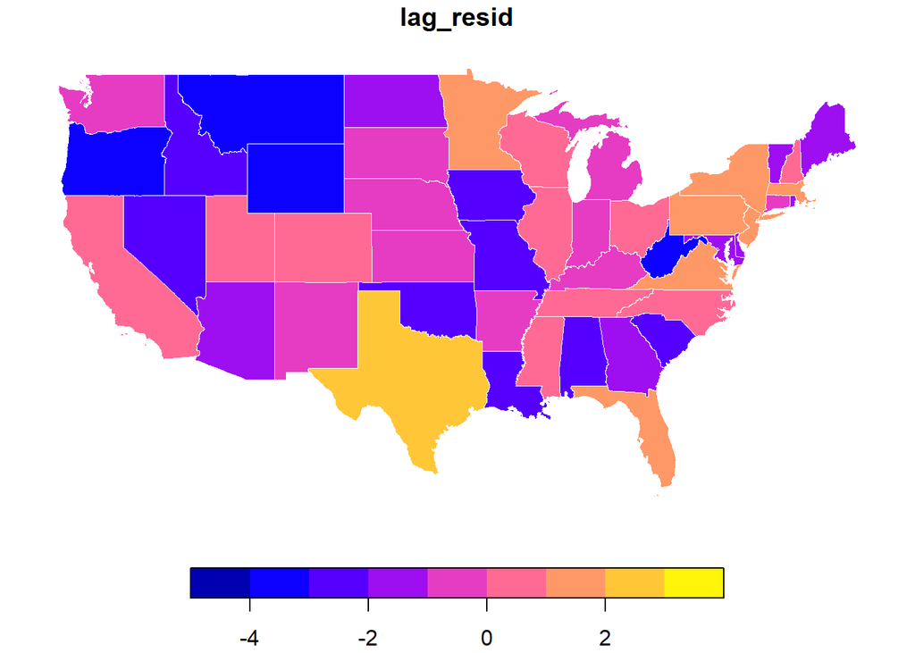

```r
final_merged_data$lag_resid <- residuals(lag)
plot(final_merged_data['lag_resid'],
     lwd=0.05,
     border=0
     )
```

## Spatial Error Modeling

In a spatial error model, we assume that our errors (our residuals) are dependent on lagged error terms. In practice, this generally means that we’re assuming that spatial auto-correlation is due to a variable we have not accounted for.

```r
err <- errorsarlm(formula = log_total_positive ~ months_of_covid + PoliticalPartiesRepublicanLeanRep + PoliticalPartiesDemocratLeanDem + densityMi,
  data = final_merged_data,
  listw = nweights)
summary(err)
```

```
##
## Call:
## errorsarlm(formula = log_total_positive ~ months_of_covid + PoliticalPartiesRepublicanLeanRep +
##     PoliticalPartiesDemocratLeanDem + densityMi, data = final_merged_data,
##     listw = nweights)
##
## Residuals:
##      Min       1Q   Median       3Q      Max
## -4.16444 -0.68126  0.15147  0.85528  3.10519
##
## Type: error
## Coefficients: (asymptotic standard errors)
##                                      Estimate  Std. Error z value  Pr(>|z|)
## (Intercept)                        1.6935e+01  1.8413e+00  9.1977 < 2.2e-16
## months_of_covid                    1.2161e-01  1.4876e-02  8.1746 2.220e-16
## PoliticalPartiesRepublicanLeanRep -1.2827e-01  2.3503e-02 -5.4574 4.831e-08
## PoliticalPartiesDemocratLeanDem   -8.3445e-02  2.2148e-02 -3.7676 0.0001648
## densityMi                         -3.0284e-04  5.6655e-05 -5.3453 9.029e-08
##
## Lambda: 0.89398, LR test value: 174.17, p-value: < 2.22e-16
## Asymptotic standard error: 0.044524
##     z-value: 20.078, p-value: < 2.22e-16
## Wald statistic: 403.15, p-value: < 2.22e-16
##
## Log likelihood: -980.7865 for error model
## ML residual variance (sigma squared): 1.5996, (sigma: 1.2648)
## Number of observations: 588
## Number of parameters estimated: 7
## AIC: 1975.6, (AIC for lm: 2147.7)
```

Note that, unlike the case of our spatial lag model, we can interpret the coefficients directly. This is because the observed autocorrelation in our OLS residuals is assumed to be due to adjacent residuals, not lagged response variables.

Inspecting a map for autocorrelation in model residuals, we again see a distribution that leads us to suspect that we’ve eliminated spatial autocorrelation.

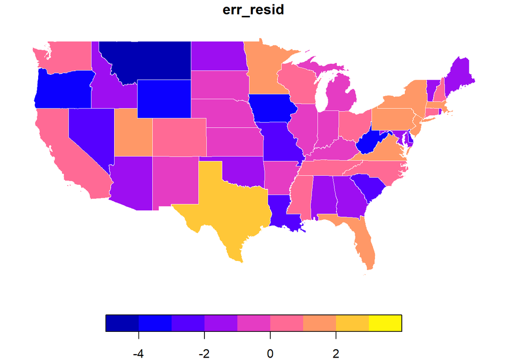

```r
final_merged_data$err_resid <- residuals(err)
plot(final_merged_data['err_resid'],
     lwd=0.05,
     border=0
     )
```

#Moran tests and plots on error modelling

```r
moran.test(final_merged_data$err_resid, nweights)
```

```
##
##  Moran I test under randomisation
##
## data:  final_merged_data$err_resid
## weights: nweights
##
## Moran I statistic standard deviate = -1.7973, p-value = 0.9639
## alternative hypothesis: greater
## sample estimates:
## Moran I statistic       Expectation          Variance
##     -1.464434e-02     -1.703578e-03      5.184103e-05
```

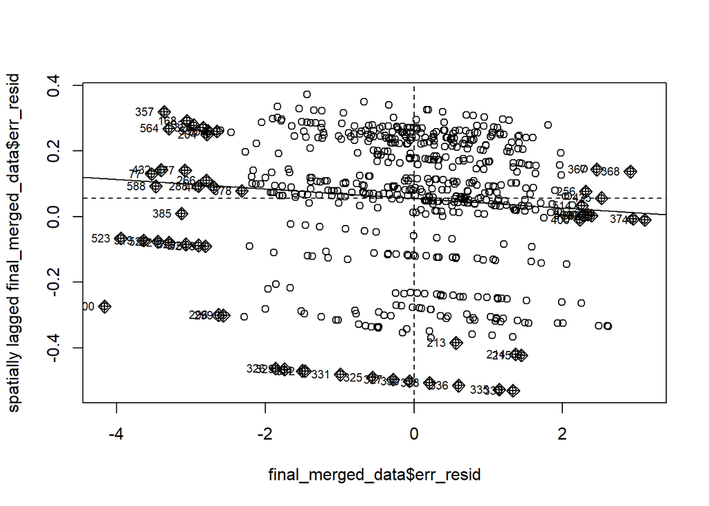

```r
moran.plot(final_merged_data$err_resid, nweights)
```

Running further analysis to decide on our model of choice.

## Akaike Information Criterion

The AIC is a statistic used to evaluate model fit.

```r
AIC(ols, err, lag)
```

```
##     df      AIC
## ols  6 2147.745
## err  7 1975.573
## lag  7 1989.123
```

On this basis, we should choose the spatial error model because it has the smallest value. Similarly, we could choose the model based on the log-likelihood alone—this is similar to the AIC, but not penalize the model for overfitting. We can examine the relationships between these evaluative criteria by printing an ANOVA table…

### Log-Likelihood

```r
anova(err, lag)
```

```
##     Model df    AIC  logLik
## err     1  7 1975.6 -980.79
## lag     2  7 1989.1 -987.56
```

We are attempting to *minimize* the AIC and *maximize* the log-likelihood. In this case, these criteria are both met by the `err` model.

### Lagrange Multiplier Tests

A *lagrange multiplier test* is another common means for evaluating the appropriateness of spatial model. This diagnostic tests the results of an OLS model for a range of forms of spatial dependence:

1. Error dependence (called `LMerr`).
2. A missing spatially lagged dependent variable (called `LMlag`).
3. Error dependence robust to the possible presence of missing lagged dependent variable (called `RLMerr`, for Robust).
4. A missing lagged dependent variable robust to the possible presence of error dependence (called `RLMlag` for Robust).

```r
legrange <- lm.LMtests(ols, nweights, test='all')
legrange
```

```
##
##  Lagrange multiplier diagnostics for spatial dependence
##
## data:
## model: lm(formula = log_total_positive ~ months_of_covid +
## PoliticalPartiesRepublicanLeanRep + PoliticalPartiesDemocratLeanDem +
## densityMi, data = final_merged_data)
## weights: nweights
##
## LMerr = 1147.9, df = 1, p-value < 2.2e-16
##
##
##  Lagrange multiplier diagnostics for spatial dependence
##
## data:
## model: lm(formula = log_total_positive ~ months_of_covid +
## PoliticalPartiesRepublicanLeanRep + PoliticalPartiesDemocratLeanDem +
## densityMi, data = final_merged_data)
## weights: nweights
##
## LMlag = 885.65, df = 1, p-value < 2.2e-16
##
##
##  Lagrange multiplier diagnostics for spatial dependence
##
## data:
## model: lm(formula = log_total_positive ~ months_of_covid +
## PoliticalPartiesRepublicanLeanRep + PoliticalPartiesDemocratLeanDem +
## densityMi, data = final_merged_data)
## weights: nweights
##
## RLMerr = 281.04, df = 1, p-value < 2.2e-16
##
##
##  Lagrange multiplier diagnostics for spatial dependence
##
## data:
## model: lm(formula = log_total_positive ~ months_of_covid +
## PoliticalPartiesRepublicanLeanRep + PoliticalPartiesDemocratLeanDem +
## densityMi, data = final_merged_data)
## weights: nweights
##
## RLMlag = 18.754, df = 1, p-value = 1.487e-05
##
##
##  Lagrange multiplier diagnostics for spatial dependence
##
## data:
## model: lm(formula = log_total_positive ~ months_of_covid +
## PoliticalPartiesRepublicanLeanRep + PoliticalPartiesDemocratLeanDem +
## densityMi, data = final_merged_data)
## weights: nweights
##
## SARMA = 1166.7, df = 2, p-value < 2.2e-16
```

Both of our non-robust tests are statistically significant, so we turn to robust tests. Between our two robust forms, the error model has a higher LM value and lower p-value. This suggests that the error model is the more appropriate model, agreeing with our model evaluation using the AIC and Log-likelihood metrics.

Reflecting on this, I agree that the Error model is best suited. Despite the lockdown, the pandemic spread for many reasons beyond the variables I used.Taking this into account, we finde that the impacts of the pandemic were felt hardest by sparely populated Blue states. This goes against may assumptions we had on the rate of infection. It is likely that denser cities had more healthcare infrastructure or had populations easier to reach with vaccines. It is also likely that the slightly reduced outcomes for republican states was from fewer tests being carried out.

All these parameters require deeper investigation and further analysis using qualitative and other quantitative measures to fully understand what went wrong.